# Explore `octopus`

# What Happened

On July 23, 2020, [Ministry of Higher Education, Science, Research and Innovation](https://www.mhesi.go.th/home/), strictly speaking its committee กรรมการข้าราชการพลเรือนในสถาบันอุดมศึกษา (ก.พ.อ.), announced the 2020 guideline for academic rank acquisition ([หลักเกณฑ์และวิธีการพิจารณาแต่งตั้งบุคคลให้ดำรงตำแหน่งผู้ช่วยศาสตราจารย์ รองศาสตราจารย์ และศาสตราจารย์ พ.ศ. ๒๕๖๓](http://www.ratchakitcha.soc.go.th/DATA/PDF/2563/E/147/T_0020.PDF)). The guideline details several ways to achieve the academic ranks including the number of academic publishings and internationally referenced textbooks. One of the ways requires certain number of citations and h-index on [SCOPUS](https://www.scopus.com/) for Associate Professorship and Professorship.

## For science, technology, engineering, medical research, etc.

- Associate Professorship
  - 10 papers on Q1/Q2 SCOPUS database, 5 of which the author is first or corresponding author
  - SCOPUS Lifetime citations of 500, excluding self-citations
  - SCOPUS Lifetime h-index of 8 or more
  - Principal investigator for at least 5 projects funded from sources outside of the one’s own institution
- Professorship
  - 10 papers on SCOPUS database since becoming an associate professor, all of which the author is first or corresponding author
  - SCOPUS Lifetime citations of 1,000, excluding self-citations
  - SCOPUS Lifetime h-index of 18 or more
  - Principal investigator for at least 10 projects funded from sources outside of the one’s own institution

## For business management, economics, etc.

- Associate Professorship
  - 5 papers on SCOPUS database, 3 of which the author is first or corresponding author
  - SCOPUS Lifetime citations of 150, excluding self-citations
  - SCOPUS Lifetime h-index of 4 or more
  - Principal investigator for at least 5 projects funded from sources outside of the one’s own institution
- Professorship
  - 10 papers on SCOPUS database since becoming an associate professor, all of which the author is first or corresponding author
  - SCOPUS Lifetime citations of, excluding self-citations, 500 for management and 200 for economics
  - SCOPUS Lifetime h-index of 8 or more
  - Principal investigator for at least 10 projects funded from sources outside of the one’s own institution

# Data

The `octopus` dataset is constructed by the following procedures:

1. We obtained the list of every person with an academic rank from Associate Professor and above from (National Academic Position)[http://www.nap.mua.go.th/FacultyRecord/SearchDataEntryIns.aspx] published by Office of the Higher Education Commission.
2. We then employed [Hope Data Annotations](https://www.facebook.com/hopedataannotations/) to romanize Thai names and search, to the best of their abilities, corresponding profiles on [SCOPUS](https://www.scopus.com/).
3. If there is a profile on [SCOPUS](https://www.scopus.com/), we obtained h-index, citation counts, and number of documents from the portal. Note that there might be cases where the profiles are not found due to human errors in romanization. Unfortunately, we cannot circumvent this problem since National Academic Position website does not disclose SCOPUS names.
4. We process the data according to `clean.ipynb`, most notably removing duplicates. We also create `field_group` based on a clustering of multilingual universal sentence encoder vectors based on field names; this is done to group over 1,000 fields into a tractable number.

# How Many People Passed The Criteria

We apply the [now-suspended](https://www.dailynews.co.th/education/783160) criteria to current Associate Professors and Professors of all flavors to see how many in which academic ranks and field groups have passed. We treat those whose profiles cannot be found on SCOPUS by our annotators as failed.

The rules we used are slightly modified to match our data availability:

1. Associate Professorship
- Natural Science and Engineering - h-index >= 8, citation counts >= 500, document counts >= 10
- Others - h-index >= 4, citation counts >= 150, document counts >= 5
2. Professorship
- Natural Science and Engineering - h-index >= 18, citation counts >= 1,000, document counts >= 20 (since we counted 10 they should have had as associate professor)
- Economics - h-index >= 8, citation counts >= 200, document counts >= 15 (since we counted 10 they should have had as associate professor)
- Others - h-index >= 8, citation counts >= 300, document counts >= 15 (since we counted 10 they should have had as associate professor)

Note that `asso_prof_sp` is special associate professor, `prof_high` is professor with higher pay, `prof_sp` is special professor, all of which are designation from the power that be.

First, we look at them one variable at a time by academic rank and field group when the SCOPUS profile is missing and NOT missing.

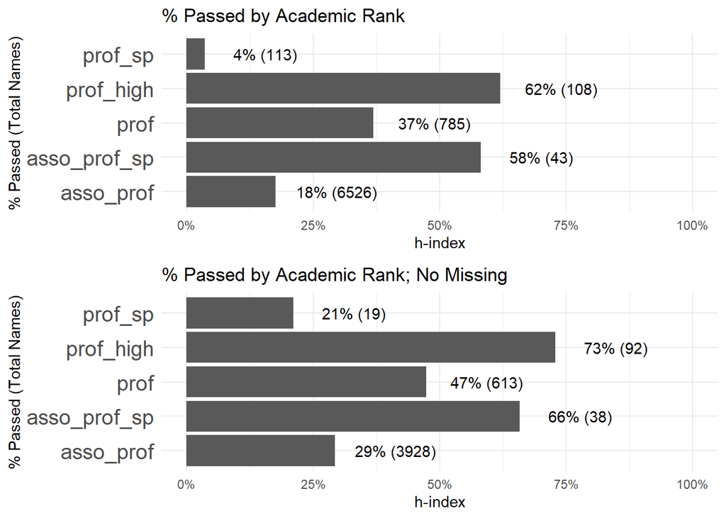

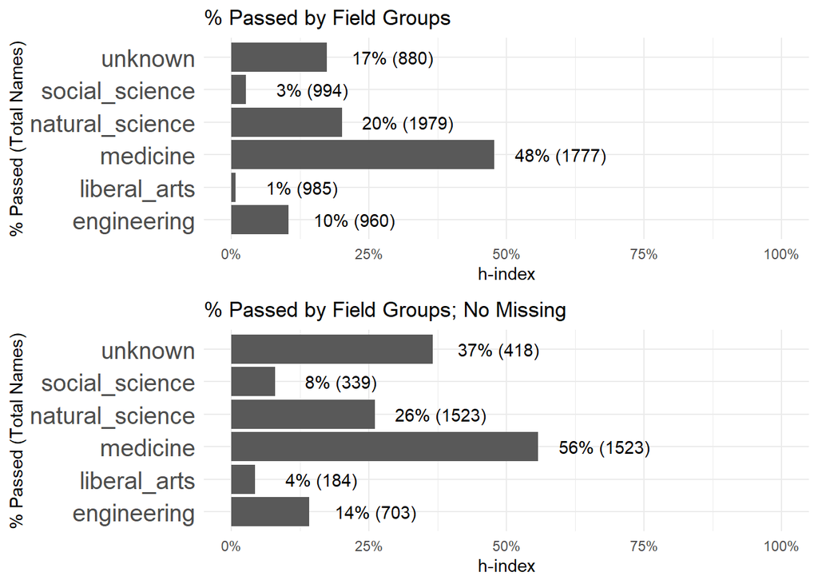

Then, we look at both of them at the same time for all names and only those who have SCOPUS profiles (We omit special ones since there are too few of them to pivot for two variables). At best, `medicine` field groups have just about half of all people passing the criteria. Clearly, this is not a very reasonable set of criteria failing half of the country’s academic researchers in the field that are doing *the best*.

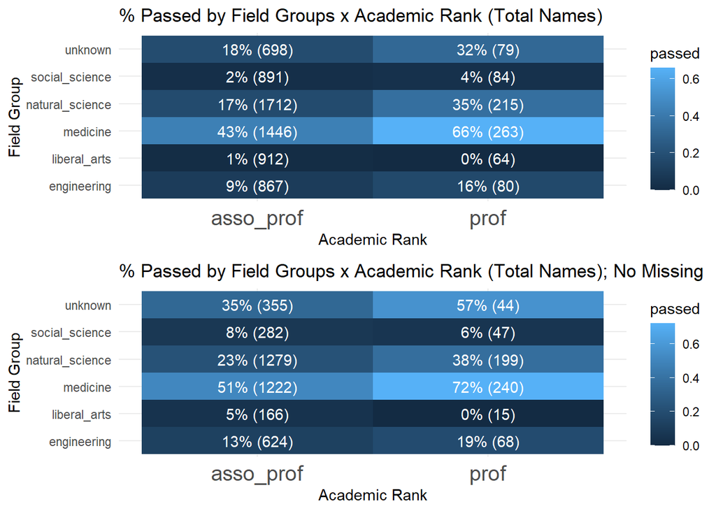

# Data-driven and More Reasonable Criteria

Assuming that we still want to use **h-index, citation counts and document counts** from SCOPUS as the main features, we can try to come up with a more reasonable criteria that does not fail 80% of all Associate Professors and Professors.

We decide to omit all 3370 names that we did not find their SCOPUS profiles. This could bias the study since some of them just might not have any publication at all but it is bias we are willing to endure over performing analysis over features that are all zeroes.

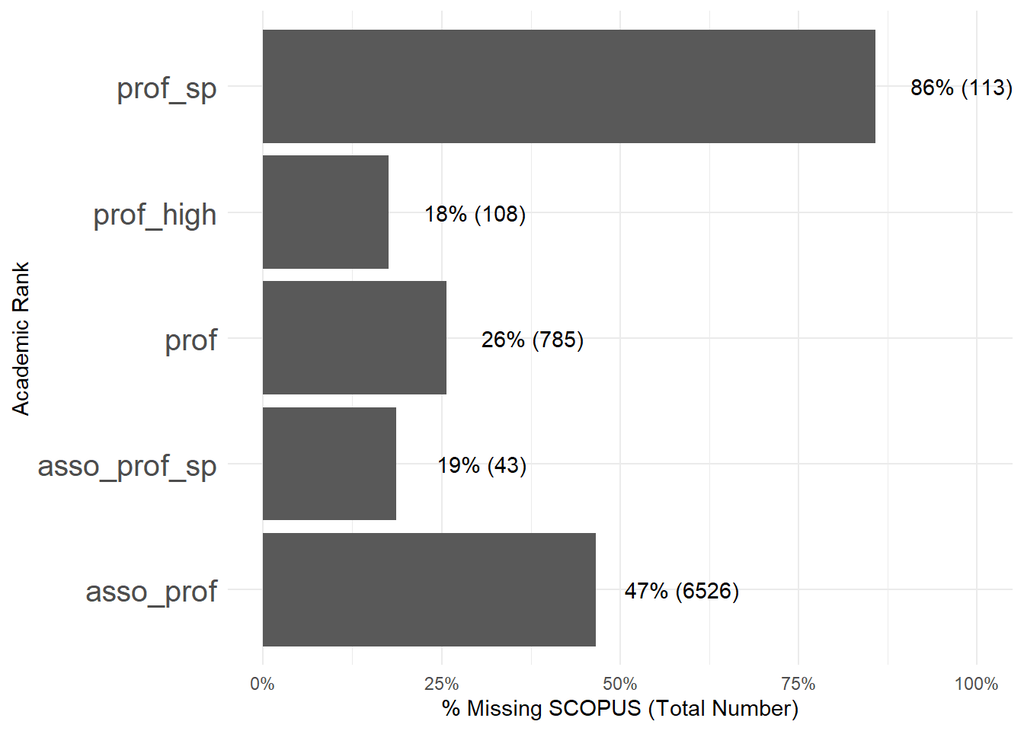

We decide to perform the analysis with the remaining 4065 names that have SCOPUS profiles. Academic ranks are also limited to regular professors and regular associate professors in to have enough samples for each subgroup.

## Xth Percentile Thresholds

The easiest option is to take a certain quantile of h-index, citation counts and document counts as a minimum criteria; for instance, taking the 20th percentile means that a newcomer should have a certain metric equal to or higher than 20% of the existing (associate) professors. We can also apply outlier detection techniques like filtering for 1.5 times interquartile range away from 25th percentile, but it turns out that does not work very well in our case.

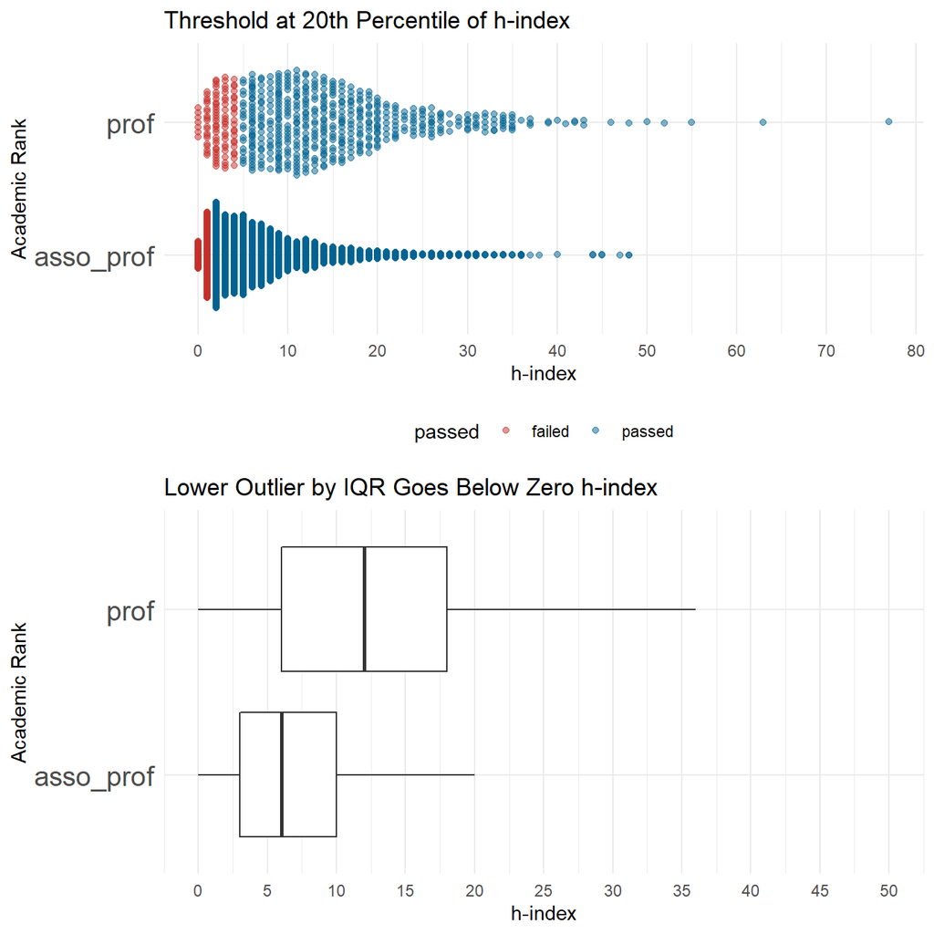

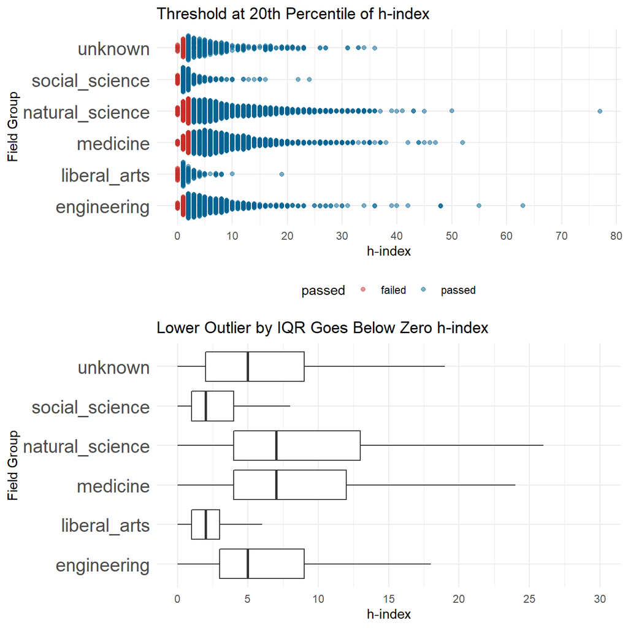

If we use this set of criteria, the thresholds for h-index, citation counts and document counts at 20th percentile will be as follows.

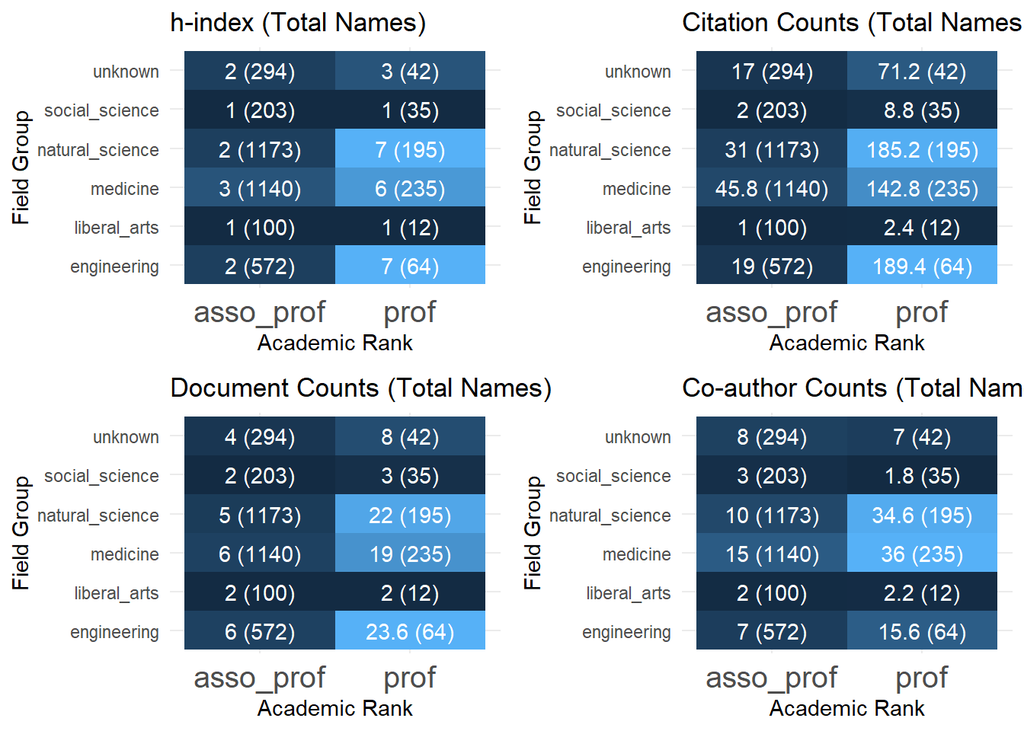

## Confidence Intervals

Another method is to assume distribution of the metrics and analytically derive the confidence intervals. When we look at the ridgeline plots, we might be able to assume that these metrics follow an exponential distribution.

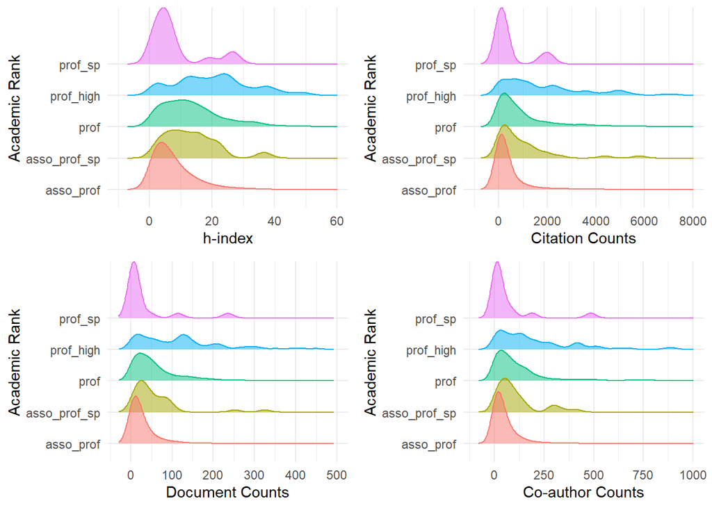

We notice one thing that the initial criteria got right: social science and liberal arts should have a different set of criteria than natural science, engineering and medicine.

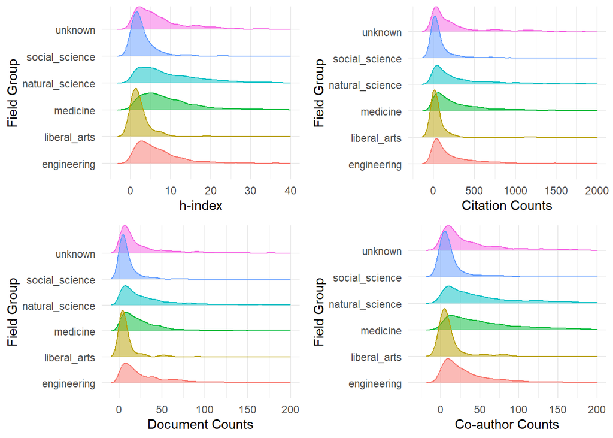

At 80% confidence interval, the thresholds are as follows.

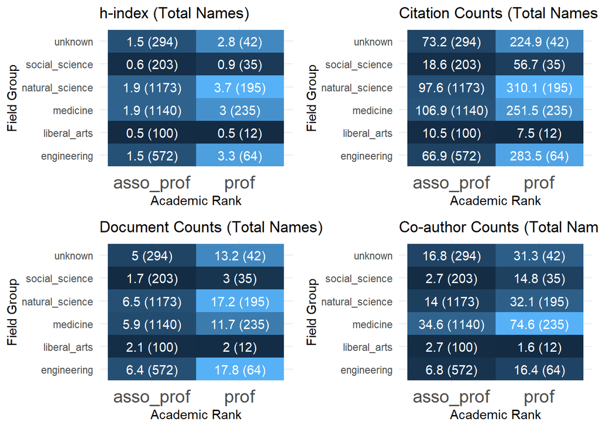

## Clustering

Instead of determining the threshold one by one, we can cluster them by optimizing for h-index, citation counts and document counts altogether.

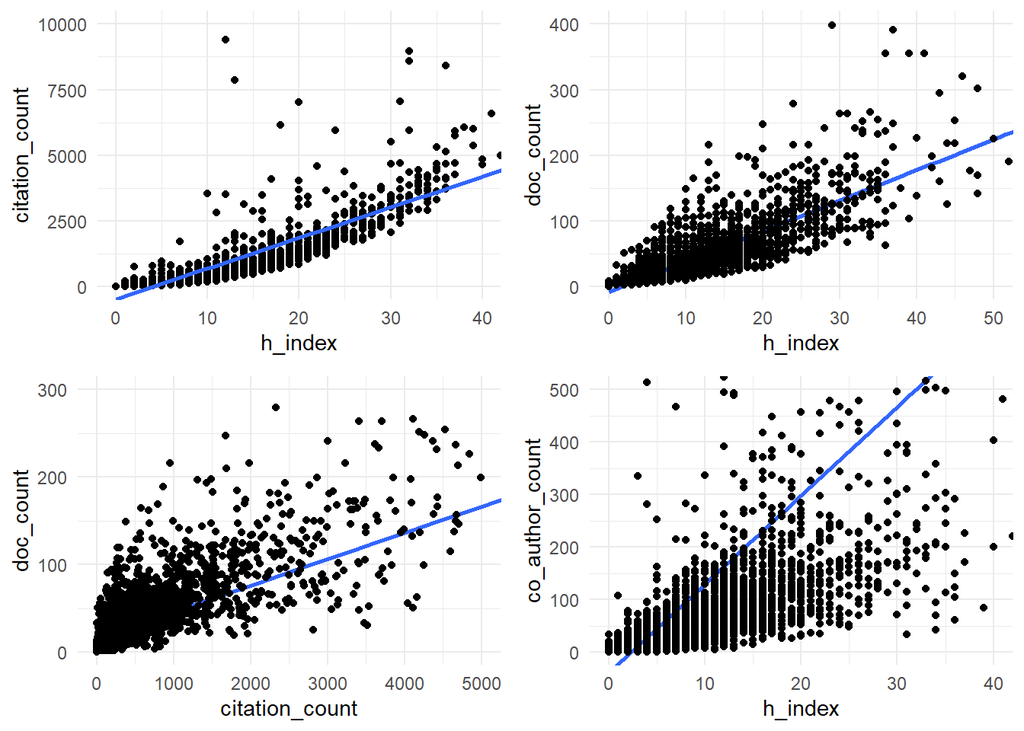

## Determine Optimal Number of Clusters

We standardize h-index, citation counts and document counts then perform k-means clustering. The optimal k is determined by plotting within-cluster sum of squares from centroids.

We learn from the previous sections that these metrics are distributed differently for natural science, medicine, engineering versus others, so we will perform the clustering for each group separately (we label them `hard_science` vs `others`).

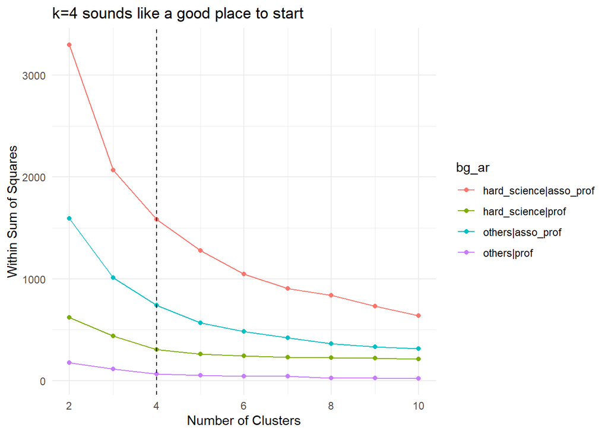

## Case Study - Find the Weakest Cluster for `others|asso_prof`

We group all 1169 names int 4 clusters. We can see that cluster 2 is “the weakest link”.

|  | cluster | nb | mean_h_index | mean_citation_count | mean_doc_count |
| --- | --- | --- | --- | --- | --- |
| 1 | 1 | 20 | 29.8 | 3379 | 118.85 |
| 2 | 2 | 747 | 2.48995983935743 | 45.1311914323962 | 7.38286479250335 |
| 3 | 3 | 309 | 8.20064724919094 | 290.171521035599 | 33.5501618122977 |
| 4 | 4 | 93 | 16.3978494623656 | 1059.90322580645 | 79.6666666666667 |

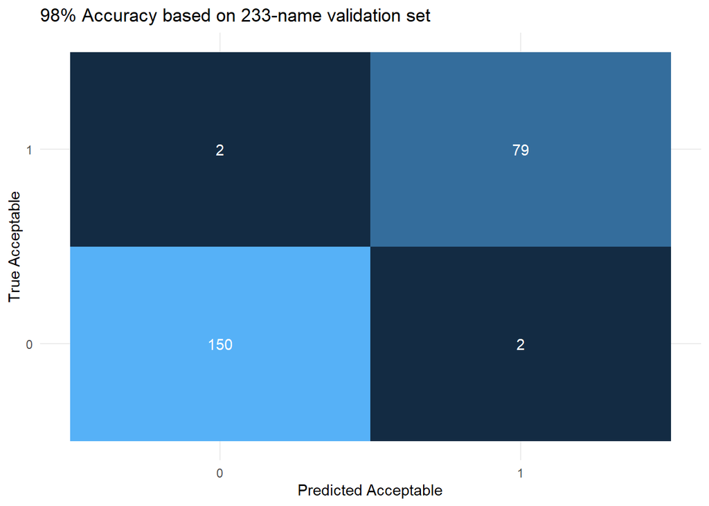

Now that we know our decision tree approach is quite reliable we use all data and visualize the rules created by the decision tree as a guideline of how we could select an associate professor from `others` fields in real life.

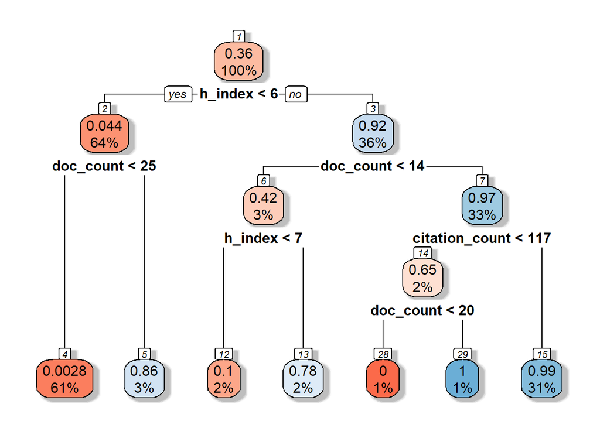